# R Notebook

Packages installation (if missing)

```r
setwd("~/R Fat Integer/data");

if (!require("readxl")) install.packages("readxl")
if (!require("dplyr")) install.packages("dplyr")
```

```r
source(file = "./WGCNA.R")
```

```
Allowing parallel execution with up to 7 working processes.
```

```r
source(file = "./fold_change_expression.R")
```

# 1. Import transcriptomic data

Data availability: https://www.ncbi.nlm.nih.gov/geo/query/acc.cgi?acc=GSE70838

```r
rownames = read_excel("src/data_transcriptome_blood_FatInteger.xlsx")[,1]
data = read_excel("src/data_transcriptome_blood_FatInteger.xlsx");
data = as.data.frame(data[-c(1:3),-1])
row.names(data) = t(rownames[-c(1:3),])
```

Take a quick look at what is in the data set:

```r
dim(data);
```

```
[1] 26322    48
```

```r
names(data);
```

```
 [1] "1"  "3"  "6"  "7"  "10" "11" "14" "16" "17" "19" "23" "26" "27" "29"
[15] "31" "33" "35" "39" "41" "42" "45" "46" "50" "53" "2"  "4"  "8"  "9"
[29] "12" "13" "15" "18" "20" "22" "25" "28" "30" "32" "34" "37" "38" "40"
[43] "43" "44" "48" "49" "54" "55"
```

```r
datExpr = as.data.frame(lapply(X = data, as.numeric));
rownames(datExpr) = rownames(data)
colnames(datExpr) = colnames(data)
```

```r
gsg = goodSamplesGenes(datExpr, verbose = 3);
```

```
 Flagging genes and samples with too many missing values...
  ..step 1
```

```r
gsg$allOK;
```

```
[1] TRUE
```

```r
sampleTree = hclust(dist(t(datExpr)), method = "average")
```

Plot the sample tree to detect outliers samples:

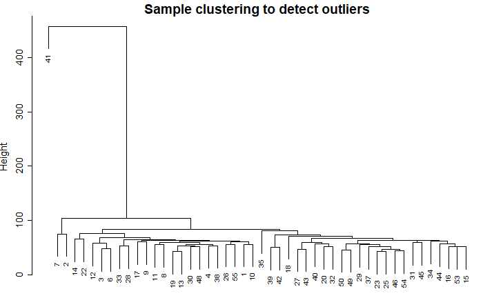

```r
sizeGrWindow(12,9)
par(cex = 0.6);
par(mar = c(0,4,2,0))
plot(sampleTree, main = "Sample clustering to detect outliers", sub="", xlab="", cex.lab = 1.5, cex.axis = 1.5, cex.main = 2)
```

One pig (#41) is detected as an outlier and further removed from the dataset due to aberrant values :

```r
#clust = cutreeStatic(sampleTree, cutHeight = 150, minSize = 10)
#keepSamples = (clust==1)
#datExpr = datExpr[,keepSamples]

#datExpr = datExpr[ , order(as.numeric(names(datExpr)))]
nProbes = ncol(datExpr)
nSamples = nrow(datExpr)

nProbes
```

```
[1] 47
```

```r
nSamples
```

```
[1] 26322
```

Save data :

```r
save(nProbes, nSamples, datExpr, file =  "./rdata/datainput/FI_transcriptomic_blood_dataInput.RData")
```

### Number of replicates per unique genes in transcriptomic dataset:

Import probes annotation data

```r
annotation = read_excel("./src/data_annotation60K_2016.xlsx", col_types = c("text", "skip", "skip", "skip", "skip", "skip", "skip", "skip", "skip", "skip", "skip", "skip", "skip", "skip", "skip", "skip", "skip", "skip", "skip", "skip", "skip", "skip", "skip", "skip", "skip", "text", "skip"))
colnames(annotation) = c("ProbeName", "Annotation")
annotation = annotation[-1,]
```

```r
save(annotation, file = "./rdata/annotation2016.RData")
```

Counting the number of replicates:

```r
summary(stats)
```

```
            Var1            Freq
 A            :    1   Min.   : 1.000
 A1BG         :    1   1st Qu.: 1.000
 A2M          :    1   Median : 2.000
 A4GALT       :    1   Mean   : 2.199
 A930006K02Rik:    1   3rd Qu.: 3.000
 AAAS         :    1   Max.   :33.000
 (Other)      :10448
```

# 2. Import phenotypic data

```r
datTraits = read_excel("./src/data_phenotypic.xlsx", col_types = c("skip", "text", "skip", "text", "text", "numeric", "numeric", "numeric", "numeric", "numeric", "numeric", "numeric"))
```

```r
summary(datTraits)
```

```
     num               line    diet         age            weight           ADG              ADFI           FCR            %loin          %backfat
 Length:47          CMJR-:24   HF:23   Min.   :124.0   Min.   :55.90   Min.   : 542.9   Min.   :1725   Min.   :2.250   Min.   :25.39   Min.   : 4.451
 Class :character   CMJR+:23   LF:24   1st Qu.:130.0   1st Qu.:72.15   1st Qu.: 778.7   1st Qu.:2169   1st Qu.:2.548   1st Qu.:27.72   1st Qu.: 6.029
 Mode  :character                      Median :132.0   Median :75.40   Median : 858.1   Median :2271   Median :2.730   Median :28.35   Median : 6.917
                                       Mean   :132.7   Mean   :75.69   Mean   : 840.2   Mean   :2280   Mean   :2.738   Mean   :28.26   Mean   : 7.093
                                       3rd Qu.:136.0   3rd Qu.:80.95   3rd Qu.: 915.3   3rd Qu.:2440   3rd Qu.:2.874   3rd Qu.:28.97   3rd Qu.: 8.109
                                       Max.   :139.0   Max.   :90.20   Max.   :1067.9   Max.   :2658   Max.   :3.279   Max.   :30.62   Max.   :10.053
```

```r
save(datTraits, file = "./rdata/datainput/datTraits.RData")
```

# 3. Quantification of the number of probes that are significantly linked to the animal phenotypic traits of interest

For each phenotypic trait we create a linear model to identify which one that most affects the expression levels of the molecular probes.

```r
table(colnames(datExpr) == datTraits$num)
```

```
TRUE
  47
```

```r
# collect residuals of linear model
df_residuals_line = datExpr
df_residuals_diet = datExpr
df_residuals_age = datExpr
df_residuals_weight = datExpr
df_residuals_ADG = datExpr
df_residuals_ADFI = datExpr
df_residuals_FCR = datExpr
df_residuals_loin = datExpr
df_residuals_backfat = datExpr


datExpr_Matrix = t(datExpr)

p_values_line = vector(length = nrow(datExpr))
p_values_diet = vector(length = nrow(datExpr))
p_values_age = vector(length = nrow(datExpr))
p_values_weight = vector(length = nrow(datExpr))
p_values_ADG = vector(length = nrow(datExpr))
p_values_ADFI = vector(length = nrow(datExpr))
p_values_FCR = vector(length = nrow(datExpr))
p_values_loin = vector(length = nrow(datExpr))
p_values_backfat = vector(length = nrow(datExpr))
```

```r
for (i in 1:nrow(datExpr)){
  md_line = lm(as.numeric(datExpr_Matrix[,i]) ~ as.factor(datTraits$line))
  md_diet = lm(as.numeric(datExpr_Matrix[,i]) ~ as.factor(datTraits$diet))
  md_age = lm(as.numeric(datExpr_Matrix[,i]) ~ as.numeric(datTraits$age))
  md_weight = lm(as.numeric(datExpr_Matrix[,i]) ~ as.numeric(datTraits$weight))
  md_ADG = lm(as.numeric(datExpr_Matrix[,i]) ~ as.numeric(datTraits$ADG))
  md_ADFI = lm(as.numeric(datExpr_Matrix[,i]) ~ as.numeric(datTraits$ADFI))
  md_FCR = lm(as.numeric(datExpr_Matrix[,i]) ~ as.numeric(datTraits$FCR))
  md_loin = lm(as.numeric(datExpr_Matrix[,i]) ~ as.numeric(datTraits$`%loin`))
  md_backfat = lm(as.numeric(datExpr_Matrix[,i]) ~ as.numeric(datTraits$`%backfat`))

  p_values_line[i] = summary(md_line)$coefficients[2,4]
  p_values_diet[i] = summary(md_diet)$coefficients[2,4]
  p_values_age[i] = summary(md_age)$coefficients[2,4]
  p_values_backfat[i] = summary(md_backfat)$coefficients[2,4]
  p_values_ADFI[i] = summary(md_ADFI)$coefficients[2,4]
  p_values_ADG[i] = summary(md_ADG)$coefficients[2,4]
  p_values_FCR[i] = summary(md_FCR)$coefficients[2,4]
  p_values_loin[i] = summary(md_loin)$coefficients[2,4]
  p_values_weight[i] = summary(md_weight)$coefficients[2,4]

  df_residuals_age[i,] = md_age$residuals
}
```

```r
x = data.frame("Variable" = c("age", "diet", "%backfat", "ADFI", "ADG", "FCR", "line", "%loin","weight"),
                "p value <0.01" = c(length(p_values_age[which(p_values_age<0.01)]),
                                    length(p_values_diet[which(p_values_diet<0.01)]),
                                    length(p_values_backfat[which(p_values_backfat<0.01)]),
                                    length(p_values_ADFI[which(p_values_ADFI<0.01)]),
                                    length(p_values_ADG[which(p_values_ADG<0.01)]),
                                    length(p_values_FCR[which(p_values_FCR<0.01)]),
                                    length(p_values_line[which(p_values_line<0.01)]),
                                    length(p_values_loin[which(p_values_loin<0.01)]),
                                    length(p_values_weight[which(p_values_weight<0.01)])),

                "p value <0.05" =c(length(p_values_age[which(p_values_age<0.05)]),
                                    length(p_values_diet[which(p_values_diet<0.05)]),
                                    length(p_values_backfat[which(p_values_backfat<0.05)]),
                                    length(p_values_ADFI[which(p_values_ADFI<0.05)]),
                                    length(p_values_ADG[which(p_values_ADG<0.05)]),
                                    length(p_values_FCR[which(p_values_FCR<0.05)]),
                                    length(p_values_line[which(p_values_line<0.05)]),
                                    length(p_values_loin[which(p_values_loin<0.05)]),
                                    length(p_values_weight[which(p_values_weight<0.05)])))
x
```

| Variable | p.value..0.01 | p.value..0.05 |
| --- | --- | --- |
| age | 1174 | 4940 |
| diet | 50 | 335 |
| %backfat | 164 | 726 |
| ADFI | 213 | 1352 |
| ADG | 325 | 1756 |
| FCR | 425 | 1682 |
| line | 1813 | 3726 |
| %loin | 359 | 1918 |
| weight | 90 | 596 |

```r
NA
```

The results of the linear regressions show that age at slaughter and line were the factors affecting the most the expression levels of molecular probes (19% of the probes significantly affected by age at slaughter and 14% by the line effect) (Supplementary Table 2).

For next steps of analysis, we used the residuals of these linear regressions for the age effect, but preserved the intra- and inter-line variability for FE.

# 4. Fold change

Only probes $i$ whose log fold-change $FC_i$ was greater than $1$ were selected, with log_2(FC_i) = max(log_2(expression_i)) - min(log_2(expression_i))

```r
table(names(df_residuals_ageabt) == rownames(datTraits))
```

```
TRUE
  47
```

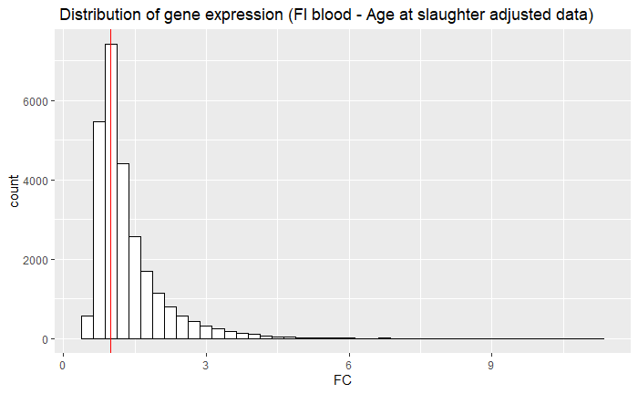

```r
datExprFoldChange = t(FoldChangeExpr(dataExpr = data, threshold = 1))
```

```r
dim(dataExprFoldChange)
```

```
[1]    47 16190
```

This reduced dataset included $16,190$ probes for the $47$ pigs.

```r
save(datExprFoldChange, file = "./rdata/datainput/FI_residuals_reduced_transcriptome.RData")
```

```r
save(datExprFoldChange, annotation, datTraits, data_FA, data_met, file = "./rdata/datainput/datainput.RData")
```